# SVM project

MGMT6770

9/23/2019

# 1 Introduction

This is an implementation of a support vector machine designed to identify short-term stock price changes, based on previous stock parameters: open, low, high, close, volume

## 1.1 Stock selected for this exercise:

I selected Tailored Brands because I wanted to see if the stock performed well or not. I had a friend that recommended purchasing this stock. I purchase and sold the stock in a short period of time. I think I may have sold too soon and am interested to see how the stock performed.

picture of the stock price

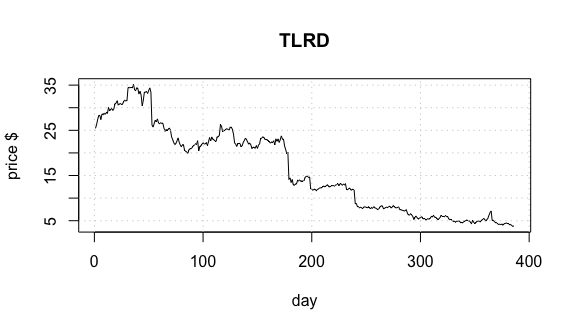

## 1.2 get data:

Names of variables in TLRD data set price.open price.high price.low price.close volume price.adjusted ret.adjusted.prices ret.closing.prices avg.change change

```r
TLRDData = read.csv('TLRDtrimmed.csv')
attach(TLRDData)
# set up data frame
TLRDDataFrame = data.frame(open=price.open, high=price.high,
        low=price.low, close=price.close,volume= volume/10000, avg_change=avg.change, change = change )
head(TLRDDataFrame)
```

```
##    open  high   low close volume avg_change change
## 1 25.62 26.37 25.57 26.23  90.87  0.8363021      U
## 2 26.02 27.40 26.01 27.37 136.15  0.9005775      U
## 3 27.64 28.48 27.15 28.22 155.50  0.1772924      E
## 4 28.01 28.79 28.01 28.31  88.44  0.2826855      E
## 5 28.55 28.70 27.38 27.38  82.10  0.8254551      U
## 6 27.83 28.80 27.58 28.63  75.47  0.2232936      E
```

```r
tail(TLRDDataFrame)
```

```
##     open high  low close volume avg_change change
## 366 5.07 5.42 5.00  5.10 808.42 -3.2576082      D
## 367 5.00 5.17 4.73  4.81 727.50 -2.8112450      D
## 368 4.83 4.84 4.47  4.54 586.93 -1.4665445      D
## 369 4.67 4.72 4.42  4.54 457.44 -1.8198787      D
## 370 4.53 4.65 4.32  4.34 511.96 -0.4257332      E
## 371 4.33 4.39 4.11  4.18 567.26 -0.8169149      D
```

```r
remove(TLRDData)
```

```r
levels(TLRDDataFrame$change)
```

```
## [1] "D" "E" "U"
```

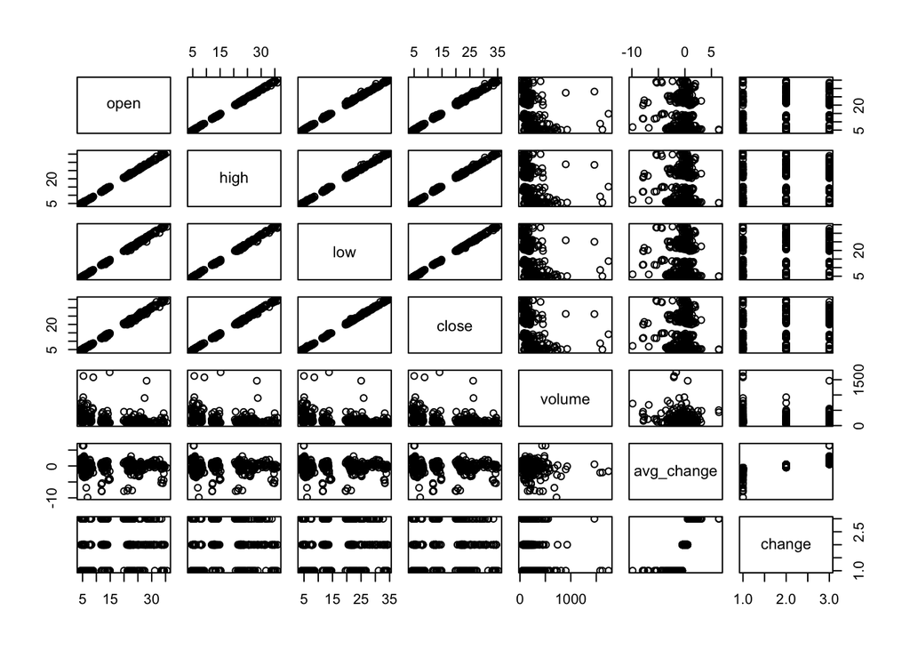

```r
plot(TLRDDataFrame)
```

## 1.3 classification model, categorical response

### 1.3.1 traditional interface:

```r
x <- subset(TLRDDataFrame, select = -change)
y <- TLRDDataFrame[1:371,]$change
model1 <- svm(x, y)

#model1 is all the data
print(model1)
```

```
##
## Call:
## svm.default(x = x, y = y)
##
##
## Parameters:
##    SVM-Type:  C-classification
##  SVM-Kernel:  radial
##        cost:  1
##
## Number of Support Vectors:  253
```

```r
summary(model1)
```

```
##
## Call:
## svm.default(x = x, y = y)
##
##
## Parameters:
##    SVM-Type:  C-classification
##  SVM-Kernel:  radial
##        cost:  1
##
## Number of Support Vectors:  253
##
##  ( 65 122 66 )
##
##
## Number of Classes:  3
##
## Levels:
##  D E U
```

## 1.4 how well did the model fit?

```r
pred <- predict(model1, x)

# Check accuracy:
table(pred, y)
```

```
##     y
## pred   D   E   U
##    D 123   0   0
##    E  14 134  22
##    U   0   0  78
```

## 1.5 decision values

```r
# compute decision values and probabilities:
pred <- predict(model1, x, decision.values = TRUE)
attr(pred, "decision.values")[1:7,]
```

```
##           U/E       U/D      E/D
## 1  0.21052712 1.2369489 1.956499
## 2  0.27428379 1.2959900 2.156347
## 3 -0.98324543 0.2816344 1.340487
## 4 -0.86255121 0.4018106 1.294045
## 5  0.03069754 1.1108989 1.899315
## 6 -0.95989285 0.3177224 1.177021
## 7 -1.00043672 0.2657611 1.081350
```

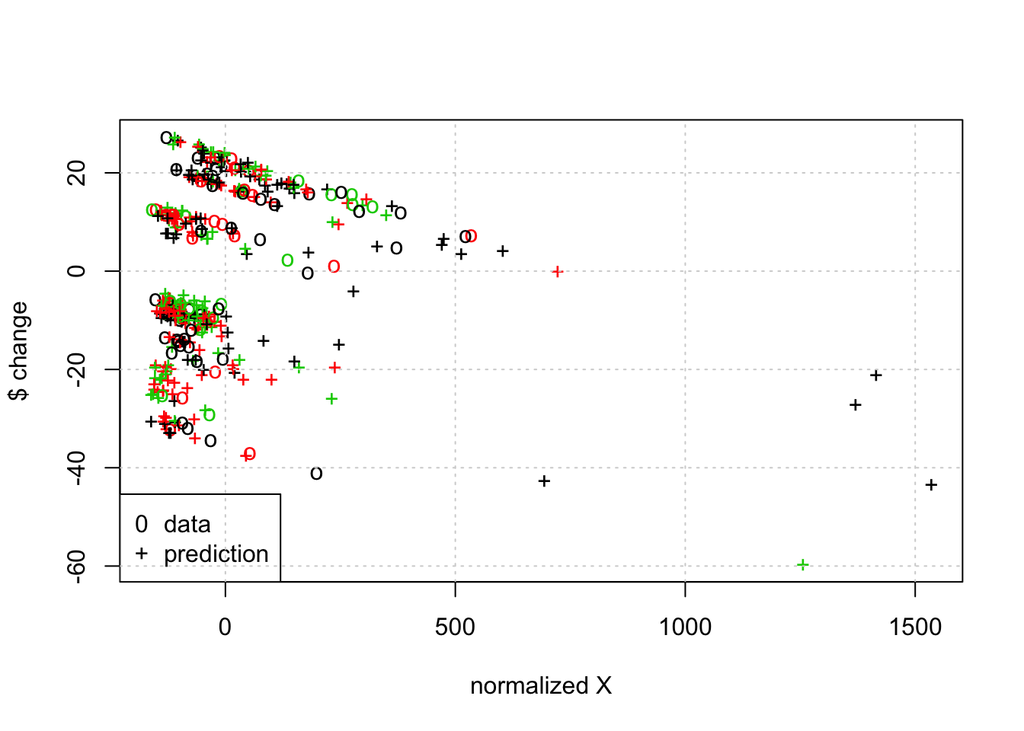

```r
# visualize (classes by color, SV by crosses):
plot(cmdscale(dist(TLRDDataFrame[,-7])),
     col = as.integer(TLRDDataFrame[,7]),xlab="normalized X", ylab = "$ change",
     pch = c("o","+")[1:150 %in% model1$index + 1])
legend('bottomleft',c('data','prediction'),pch=c('0','+'))
grid()
```

# 2 train and test set:

```r
pctTrain=0.70   # use about 70% of the the data
nObs = length(x[,1])
nObs = 371
nTrain = round(pctTrain*nObs,0)

# next line take data in order
#TrainSetIndex = 1:nTrain

# take these lines as a random sample
scramble = sample(1:nObs)
TrainSetIndex = scramble[1:nTrain]
TestSetIndex = scramble[(nTrain+1):nObs]
```

## 2.1 set up training set, test set

```r
# first the training set

TLRDDataFrame1 = TLRDDataFrame[1:371,]

XtrainSet = TLRDDataFrame[TrainSetIndex,-7]
YtrainSet = TLRDDataFrame$change[TrainSetIndex]
```

## 2.2 get the model from training set..

This is model2

```r
model2 <- svm(XtrainSet, YtrainSet)

print(model2)
```

```
##
## Call:
## svm.default(x = XtrainSet, y = YtrainSet)
##
##
## Parameters:
##    SVM-Type:  C-classification
##  SVM-Kernel:  radial
##        cost:  1
##
## Number of Support Vectors:  188
```

```r
summary(model2)
```

```
##
## Call:
## svm.default(x = XtrainSet, y = YtrainSet)
##
##
## Parameters:
##    SVM-Type:  C-classification
##  SVM-Kernel:  radial
##        cost:  1
##
## Number of Support Vectors:  188
##
##  ( 85 51 52 )
##
##
## Number of Classes:  3
##
## Levels:
##  D E U
```

## 2.3 now the test set..

```r
XtestSet = TLRDDataFrame[(nTrain:nObs),-7]
YtestSet = TLRDDataFrame$change[nTrain:nObs]
```

## 2.4 and evaluate with the test data

```r
pred2 <- predict(model2, XtestSet)
# And the accuracy..

table(pred2, YtestSet)
```

```
##      YtestSet
## pred2  D  E  U
##     D 51  4  0
##     E  3 24  7
##     U  0  0 23
```